# act_report

## WHICH DOG POST GOT THE MOST LIKES?

In this article , the posts from the *WeRateDogs* twitter page with the most likes is being looked. Data was gathered from three different sources and cleaned to make it free of quality and tidiness issues before performing some analysis to bring forth the answer to the question: **which dog post got the most likes?**

[figure not shown]

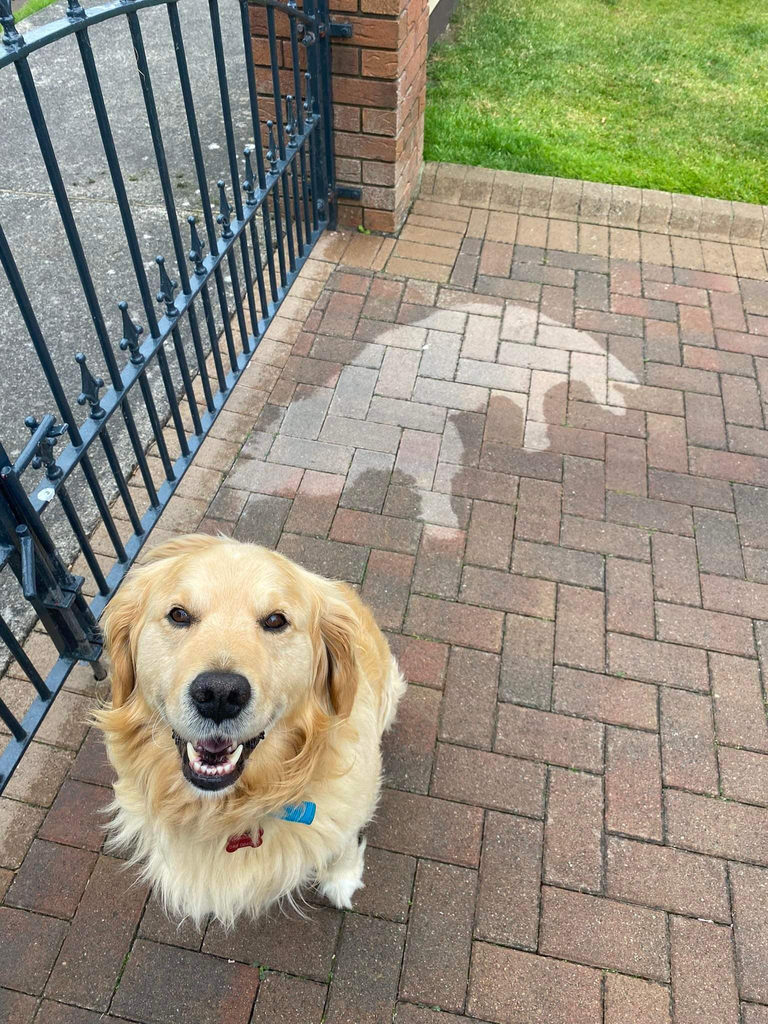

*WeRateDogs* is a twitter page that rates dogs under a denominator of `10`, over a numerator greater than `10`.**Why this rating systen?** , because the dogs being rated are just too cute and adorable. In my analysis, I was able to analyse the cleaned data to make a conclusion on which post had the most likes.

Below is a visualization of the top 10 most liked post, the highest bar representing the answer I sought after in this article.

**This image shows the top most liked post on WeRateDogs**

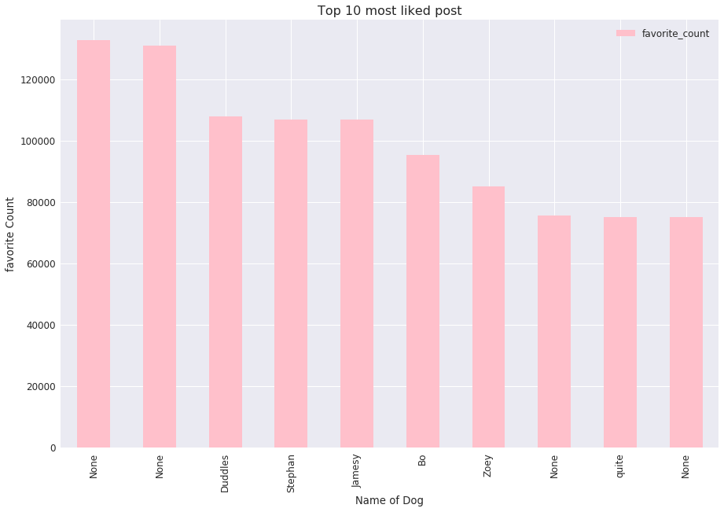

The post **'Here's a super supportive puppo participating in the Toronto #WomensMarch today.'** has the most likes.Unfortunately the name of the dog in the post wasn't captured,but from screenshot below the dog's stage is puppo

Below is a screenshot of the dataframe 'most_liked_post' with the highest liked post put first.

[figure not shown]